# Machine Learning

Joel Calixto

31 de julio de 2016

## Executive Summary

From the dataset get from groupware.les.inf.puc-rio.br/har we need generate a model for the project of Machine Learning and answer 20 question from there. I generate two models by this section , one for Descision Trees and other for Random Forest.

The data was get from this url

The training data for this project are available here: https://d396qusza40orc.cloudfront.net/predmachlearn/pml-training.csv

The test data are available here: https://d396qusza40orc.cloudfront.net/predmachlearn/pml-testing.csv

The data for this project come from this source: http://groupware.les.inf.puc-rio.br/har.

```r
library(knitr);library("dplyr");library(caret);library(randomForest);
library(rattle); library(AppliedPredictiveModeling);
library(rpart);library(rpart.plot);
library(plyr);library(dplyr);
set.seed(1307);
```

# Data load

First prepare data loading from url

```r
Url_for_train <-"https://d396qusza40orc.cloudfront.net/predmachlearn/pml-training.csv"
Url_for_test <- "https://d396qusza40orc.cloudfront.net/predmachlearn/pml-testing.csv"
train <- "pml-training.csv"
test  <- "pml-testing.csv"
if (!file.exists("./data")) {
    dir.create("./data")
}
if (!file.exists(train)) {
    download.file(Url_for_train, destfile=paste("./data/",train), method="curl")
}
if (!file.exists(test)) {
    download.file(Url_for_test, destfile=paste("./data/",test), method="curl")
}
```

load data from local disk

```r
#reuse var for load local data in enviroment
training <- read.csv(paste("./data/","pml-training.csv"), na.strings = c("NA", "#DIV/0!", ""))
testing  <- read.csv(paste("./data/","pml-testing.csv"), na.strings = c("NA", "#DIV/0!", ""))
```

# clean data, avoid NA columns from dataSet

```r
##str(training);str(testing)
dim(training); dim(testing)
```

```
## [1] 19622   160
```

```
## [1]  20 160
```

```r
trainning_clear<-training[, colSums(is.na(testing))==0]
testing_clear<-testing[,colSums(is.na(testing))==0]
```

remove col irrelevants for our analysis

```r
trainning_clear  <- trainning_clear[, -c(1:7)]
testing_clear   <- testing_clear[, -c(1:7)]
```

check new data set dimensions

```r
dim(trainning_clear); dim(testing_clear)
```

```
## [1] 19622    53
```

```
## [1] 20 53
```

generate a partition for new trainning and testing dataset

```r
trainning_with_partition<-createDataPartition(trainning_clear$classe,p=0.75,list=FALSE)
trainning_for_work<-trainning_clear[trainning_with_partition,]
testing_for_work<-trainning_clear[-trainning_with_partition,]
```

# Model selection

first probe Descision Trees

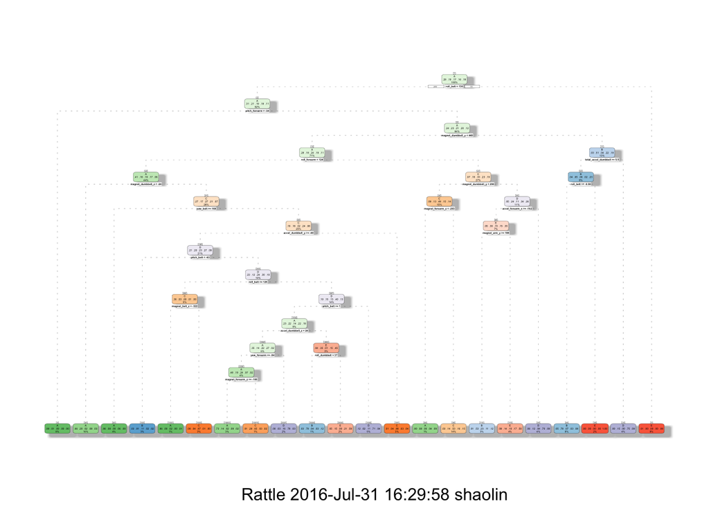

```r
#create a a model of desicion trees
DT_model<-rpart(classe~. , trainning_for_work, method="class")
#check a plot for this model
fancyRpartPlot(DT_model)
```

```r
#generate a prediction - evaluate a model
compare_dt<- predict( DT_model, testing_for_work, type="class")
#calculate the accuracy
confusion_compare_dt<-confusionMatrix(compare_dt, testing_for_work$classe)
confusion_compare_dt
```

```
## Confusion Matrix and Statistics
##
##           Reference
## Prediction    A    B    C    D    E
##          A 1253  210   25  100   41
##          B   28  510   70   26   53
##          C   40  119  689  116  109
##          D   55   67   46  498   50
##          E   19   43   25   64  648
##
## Overall Statistics
##
##                Accuracy : 0.7337
##                  95% CI : (0.7211, 0.746)
##     No Information Rate : 0.2845
##     P-Value [Acc > NIR] : < 2.2e-16
##
##                   Kappa : 0.6613
##  Mcnemar's Test P-Value : < 2.2e-16
##
## Statistics by Class:
##
##                      Class: A Class: B Class: C Class: D Class: E
## Sensitivity            0.8982   0.5374   0.8058   0.6194   0.7192
## Specificity            0.8928   0.9552   0.9052   0.9468   0.9623
## Pos Pred Value         0.7692   0.7424   0.6421   0.6955   0.8110
## Neg Pred Value         0.9566   0.8959   0.9567   0.9269   0.9384
## Prevalence             0.2845   0.1935   0.1743   0.1639   0.1837
## Detection Rate         0.2555   0.1040   0.1405   0.1015   0.1321
## Detection Prevalence   0.3322   0.1401   0.2188   0.1460   0.1629
## Balanced Accuracy      0.8955   0.7463   0.8555   0.7831   0.8407
```

Now we generate a Random Forest model

```r
#generate a model
RF_model<-randomForest(classe~. , trainning_for_work, method="class")
#generate a prediction - evaluate a model
compare_rf<-predict(RF_model, testing_for_work, type = "class")
#calculate the accuracy
confusion_compare_rf<-confusionMatrix(compare_rf,testing_for_work$classe)
confusion_compare_rf
```

```
## Confusion Matrix and Statistics
##
##           Reference
## Prediction    A    B    C    D    E
##          A 1392    2    0    0    0
##          B    1  946    2    0    0
##          C    2    1  853    5    0
##          D    0    0    0  798    0
##          E    0    0    0    1  901
##
## Overall Statistics
##
##                Accuracy : 0.9971
##                  95% CI : (0.9952, 0.9984)
##     No Information Rate : 0.2845
##     P-Value [Acc > NIR] : < 2.2e-16
##
##                   Kappa : 0.9964
##  Mcnemar's Test P-Value : NA
##
## Statistics by Class:
##
##                      Class: A Class: B Class: C Class: D Class: E
## Sensitivity            0.9978   0.9968   0.9977   0.9925   1.0000
## Specificity            0.9994   0.9992   0.9980   1.0000   0.9998
## Pos Pred Value         0.9986   0.9968   0.9907   1.0000   0.9989
## Neg Pred Value         0.9991   0.9992   0.9995   0.9985   1.0000
## Prevalence             0.2845   0.1935   0.1743   0.1639   0.1837
## Detection Rate         0.2838   0.1929   0.1739   0.1627   0.1837
## Detection Prevalence   0.2843   0.1935   0.1756   0.1627   0.1839
## Balanced Accuracy      0.9986   0.9980   0.9978   0.9963   0.9999
```

# Conclusion

For the accuracy level of Random Forest we choose this model over descisions tree

# Answers for quiz

check answers for quiz of project Finally generate a answer for quiz

```r
final<-predict(RF_model, testing_clear)
final
```

```
##  1  2  3  4  5  6  7  8  9 10 11 12 13 14 15 16 17 18 19 20
##  B  A  B  A  A  E  D  B  A  A  B  C  B  A  E  E  A  B  B  B
## Levels: A B C D E
```